# lazyIris examples

[Phil](https://github.com/phil8192/lazy-iris)

2015-09-05

# Overview

*lazyIris* is a small implementation of k-nearest neighbours applied to the famous iris dataset.

# Installing

First, ensure that the devtools package is installed and then install directly from the package github [repository](https://github.com/phil8192/lazy-iris).

```r
## check for and install devtools.
# install.packages("devtools")

# install and load.
# devtools::install_github("phil8192/lazy-iris")
require(lazyIris)
```

# Loading data

The package has preprocessed iris data attached.

```r
attach(iris.data)
```

Example data may be loaded from the inst/extdata directory by using the *loadData* function. In addition, the *checkData* function will perform any necessary data sanity checks.

```r
iris.data <- checkData(loadData())
```

```
##   cleaned data...
##   sepal.length    sepal.width     petal.length   petal.width
##  Min.   :4.300   Min.   :2.000   Min.   :1.00   Min.   :0.100
##  1st Qu.:5.100   1st Qu.:2.800   1st Qu.:1.60   1st Qu.:0.300
##  Median :5.800   Median :3.000   Median :4.40   Median :1.300
##  Mean   :5.856   Mean   :3.056   Mean   :3.78   Mean   :1.209
##  3rd Qu.:6.400   3rd Qu.:3.300   3rd Qu.:5.10   3rd Qu.:1.800
##  Max.   :7.900   Max.   :4.400   Max.   :6.90   Max.   :2.500
##             species
##  Iris-setosa    :48
##  Iris-versicolor:50
##  Iris-virginica :49
##
##
##
```

# A quick look at the data

The dataset consists of 4 features and 3 possible classes. Some of the features are highly correlated:

```r
cor(iris.data[, 1:4])
```

|  | sepal.length | sepal.width | petal.length | petal.width |
| --- | --- | --- | --- | --- |
| sepal.length | 1.0000000 | -0.1093208 | 0.8713046 | 0.8170583 |
| sepal.width | -0.1093208 | 1.0000000 | -0.4210574 | -0.3563762 |
| petal.length | 0.8713046 | -0.4210574 | 1.0000000 | 0.9618828 |
| petal.width | 0.8170583 | -0.3563762 | 0.9618828 | 1.0000000 |

## Iris data visualisation

The package provides a means to visualise the relationship between the 4 features and the corresponding class.

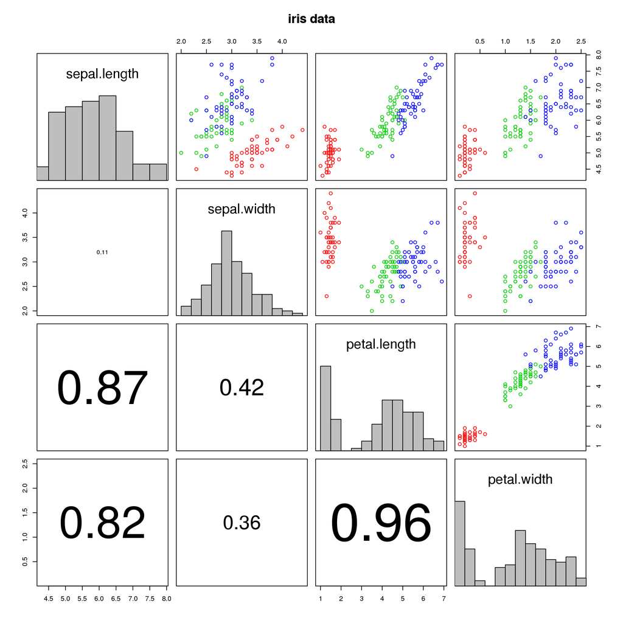

```r
# plot all the data.
visualise(iris.data, class.name="species", main="iris data", plot.hist=TRUE,
    plot.cor=TRUE)
```

In the above visualisation, the colours correspond to the classification of the species of iris plant:

| colour | species |
| --- | --- |
| red | Iris setosa |
| green | Iris versicolour |
| blue | Iris virginica |

The lower left panels show the correlation between the 4 iris features, the diagonal panels contain a histogram of the distribution of each feature, and finally, the upper right panels contain scatter plots of each possible feature combination colour coded by species.

# Querying the data

The *knn* function makes it possible to query the data for neighbouring instances given an arbitrary list of features.

## 10-Nearest neighbours

The following example obtains the *top 10* nearest neighbours to query:

```r
# form the query.
# in this example, the feature values are actually the mean values in the
# dataset, thus the results may be interpreted as the top 10 "most average"
# instances.

query <- list(
    sepal.length=5.84,
    sepal.width=3.05,
    petal.length=3.76,
    petal.width=1.20)

# obtain the nearest-neighbours.
top.10 <- knn(query, iris.data, 10)
print(top.10, row.names=FALSE)
```

| sepal.length | sepal.width | petal.length | petal.width | species | distance |
| --- | --- | --- | --- | --- | --- |
| 5.6 | 2.9 | 3.6 | 1.3 | Iris-versicolor | 0.3401470 |
| 5.8 | 2.7 | 3.9 | 1.2 | Iris-versicolor | 0.3790778 |
| 5.6 | 3.0 | 4.1 | 1.3 | Iris-versicolor | 0.4309292 |
| 6.1 | 2.8 | 4.0 | 1.3 | Iris-versicolor | 0.4446347 |
| 5.7 | 2.8 | 4.1 | 1.3 | Iris-versicolor | 0.4557412 |
| 5.7 | 3.0 | 4.2 | 1.2 | Iris-versicolor | 0.4644351 |
| 5.7 | 2.9 | 4.2 | 1.3 | Iris-versicolor | 0.4956813 |
| 5.8 | 2.6 | 4.0 | 1.2 | Iris-versicolor | 0.5115662 |
| 5.8 | 2.7 | 4.1 | 1.0 | Iris-versicolor | 0.5288667 |
| 5.9 | 3.0 | 4.2 | 1.5 | Iris-versicolor | 0.5382379 |

## Classification

In addition to the N-nearest neighours, the function also returns the distance from the query point. This distance can be used to predict the most likely class of the query point using the *classifier* function.

```r
prediction <- classifier(top.10$species, top.10$distance)
print(paste("prediction =", prediction$pred,
            "confidence =", prediction$conf))
```

```
## [1] "prediction = Iris-versicolor confidence = 1"
```

## Visualising a query result for Versicolour (green)

Given a list of nearest neighbours returned from the *knn* function, it is possible to visualise the query point and it’s nearest neighbours over all dimensions in the feature space by using the *visualise* function.

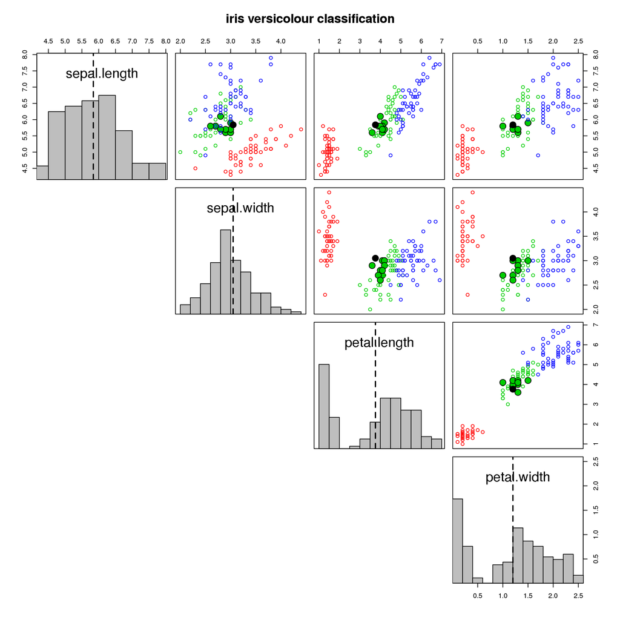

```r
# visualise the result.
visualise(iris.data, class.name="species", query=query, neighbours=top.10,
    main="iris versicolour classification", plot.hist=TRUE, plot.cor=FALSE)
```

In the above plot, the query point is shown as a black point. The resulting neighbours from the *knn* query are highlighted (opaque) circles.

In addition, the query point with respect to the distribution of features has been highlighted with a black dashed vertical line over the corresponding feature histograms. Clearly the query point is within the Iris versicolour cluster (green).

## Versicolour or Virginica (green/blue)

Closer to a decision boundary (which is non-linear for iris data), the class to which the query point belongs to is ambiguous:

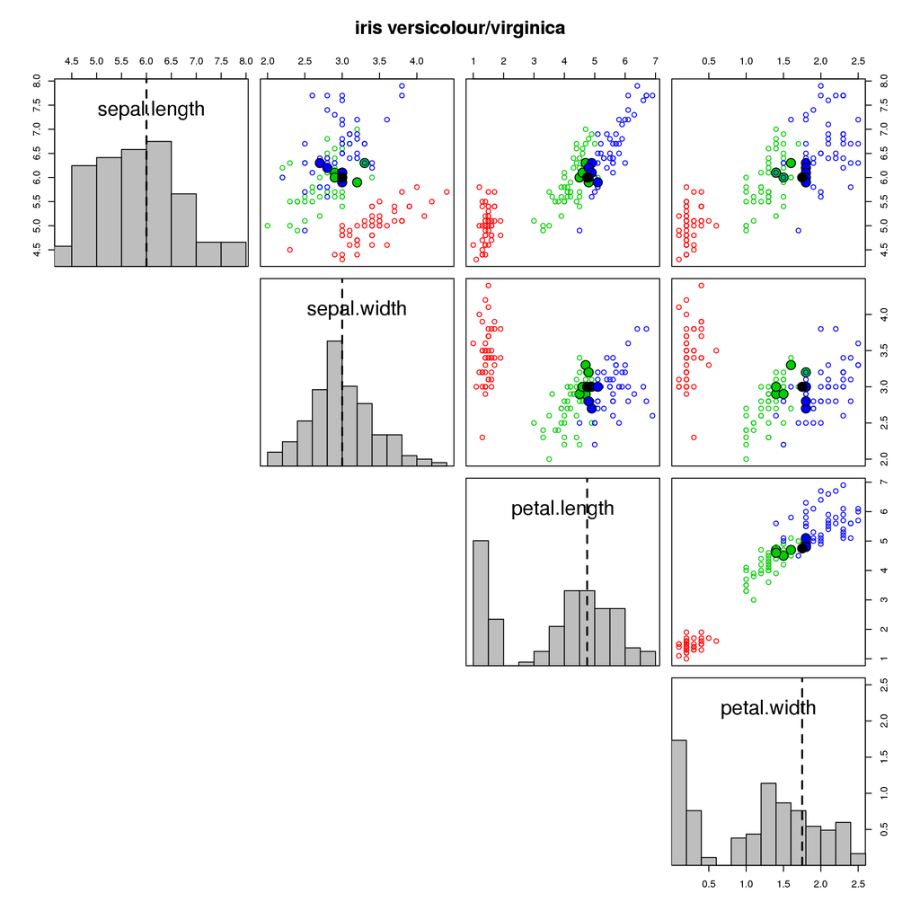

```r
q <- list(sepal.length=6, sepal.width=3, petal.length=4.75, petal.width=1.75)
top.10 <- knn(q, iris.data, k=10)
visualise(iris.data, class.name="species", query=q, neighbours=top.10,
    main="iris versicolour/virginica", plot.hist=TRUE, plot.cor=FALSE)
```

From the *top 10 results*:

```r
print(top.10, row.names=F)
```

| sepal.length | sepal.width | petal.length | petal.width | species | distance |
| --- | --- | --- | --- | --- | --- |
| 6.0 | 3.0 | 4.8 | 1.8 | Iris-virginica | 0.0707107 |
| 6.1 | 3.0 | 4.9 | 1.8 | Iris-virginica | 0.1870829 |
| 5.9 | 3.2 | 4.8 | 1.8 | Iris-versicolor | 0.2345208 |
| 6.2 | 2.8 | 4.8 | 1.8 | Iris-virginica | 0.2915476 |
| 5.9 | 3.0 | 5.1 | 1.8 | Iris-virginica | 0.3674235 |
| 6.0 | 2.9 | 4.5 | 1.5 | Iris-versicolor | 0.3674235 |
| 6.1 | 2.9 | 4.7 | 1.4 | Iris-versicolor | 0.3807887 |
| 6.1 | 3.0 | 4.6 | 1.4 | Iris-versicolor | 0.3937004 |
| 6.3 | 3.3 | 4.7 | 1.6 | Iris-versicolor | 0.4527693 |
| 6.3 | 2.7 | 4.9 | 1.8 | Iris-virginica | 0.4527693 |

The 10 (unweighted) neighbours yield a 50/50 classification:

```r
prediction <- with(knn(q, iris.data, k=10), classifier(species, distance))
with(prediction, paste0("prediction = ", pred, " confidence = ", conf*100, "%"))
```

```
## [1] "prediction = Iris-versicolor confidence = 50%"
```

## A very peculiar iris…

A rare iris was discovered. It had petals as large as an iris versicolor, and a stem the size of a setosa…

```r
# construct query as the mean iris setosa type.
q <- as.list(colMeans(iris.data[iris.data$species == "Iris-setosa", 1:4]))
q$petal.width <- 4*q$petal.width
q$petal.length <- 1.75*q$petal.length
print(unlist(q))
```

| sepal.length | sepal.width | petal.length | petal.width |
| --- | --- | --- | --- |
| 5.010417 | 3.43125 | 2.559375 | 1 |

Given the 10 nearest known neighbours to the disovery:

```r
top.10 <- knn(q, iris.data, k=10)
print(top.10, row.names=F)
```

| sepal.length | sepal.width | petal.length | petal.width | species | distance |
| --- | --- | --- | --- | --- | --- |
| 5.1 | 3.8 | 1.9 | 0.4 | Iris-setosa | 0.9689051 |
| 5.1 | 3.3 | 1.7 | 0.5 | Iris-setosa | 1.0068650 |
| 5.1 | 2.5 | 3.0 | 1.1 | Iris-versicolor | 1.0389428 |
| 5.0 | 3.5 | 1.6 | 0.6 | Iris-setosa | 1.0417464 |
| 4.8 | 3.4 | 1.9 | 0.2 | Iris-setosa | 1.0583133 |
| 5.0 | 3.4 | 1.6 | 0.4 | Iris-setosa | 1.1320271 |
| 5.4 | 3.9 | 1.7 | 0.4 | Iris-setosa | 1.2124468 |
| 5.4 | 3.4 | 1.7 | 0.2 | Iris-setosa | 1.2374478 |
| 5.1 | 3.7 | 1.5 | 0.4 | Iris-setosa | 1.2500109 |
| 4.8 | 3.4 | 1.6 | 0.2 | Iris-setosa | 1.2671433 |

The discovery is a most likely (90% by majority voting) *setosa*…

```r
unlist(classifier(top.10$species, top.10$distance))
```

| pred | conf |
| --- | --- |
| Iris-setosa | 0.9 |

Which can be seen in the following visualisation…

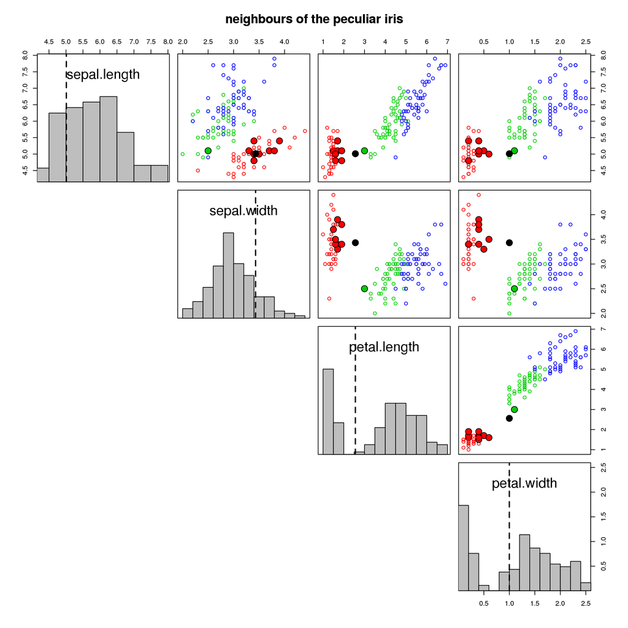

```r
visualise(iris.data, class.name="species", query=q, neighbours=top.10,
    main="neighbours of the peculiar iris", plot.hist=TRUE, plot.cor=FALSE)
```

In the interest of [sampling bias](https://en.wikipedia.org/wiki/Selection_bias), The discovery was hastily discarded.